# Lecture 8

Universal Kriging and Block Kriging

2024-12-04

## Recall from the last lecture

So far we have looked at geostatistical interpolation with:

- Simple Kriging
- Ordinary Kriging

## Recall from the last lecture

*Let´s look at the Kriging equation and its components:*

$\hat{Z}_i = \mu + e_i$

The two components can be understood as:

$\hat{Z}_i$ = global mean + local variation

## Recall from the last lecture

**Simple Kriging:**

- assume the mean $\mu$ to be known and constant
- model local variation $e(s_0)$ as a weighted linear combination of the local variation at the known points $\lambda (Z-\mu)$, then add the mean: $\hat{Z}(s_0) = \mu + \lambda (Z-\mu)$  
  with $\lambda = v' V^{-1}$ (see last lecture)

**Ordinary Kriging:**

- assume the global mean $\mu$ to be constant but *unknown*
- model global mean $\mu$ and local variation $\lambda (Z-\mu)$ at the same time by estimating the absolute value $\hat{Z}(s_0)$ and making sure that the weights $\lambda$ sum up to 1

## Recall from the last lecture

We also saw what to do when the mean is *varying* but *known*:

- this is simple kriging with a vector of known means $\mu(s) = (\mu(s_1),\mu(s_2),...,\mu(s_n))'$.

## Recall from the last lecture

So far we have looked at geostatistical interpolation with:

- known and constant mean: Simple Kriging
- unknown and constant mean: Ordinary Kriging
- known, but varying mean: Simple Kriging with mean $\mu(s) = (\mu(s_1),\mu(s_2),...,\mu(s_n))'$.

*What if the mean is unknown and varying?*

## Unknown, varying mean - Universal Kriging

- Universal Kriging assumes the mean to be varying (trend/external drift) and unknown
- seeks to model the two components simultaneously
- needs a model for both, the trend and the local variation (covariance structure)

## Unknown, varying mean - Universal Kriging

**Predictor:**

$$\hat{Z}(s_0) = x(s_0)\hat{\beta} + v'V^{-1} (Z-X\hat{\beta})$$
with $x(s_0) = (X_0(s_0),...,X_p(s_0))$ and $\hat{\beta} = (X'V^{-1}X)^{-1} X'V^{-1}Z$

it has prediction error variance
$$\sigma^2(s_0) = \sigma^2_0 - v'V^{-1}v + Q$$

with $Q = (x(s_0) - X'V^{-1}v)'(X'V^{-1}X)^{-1}(x(s_0) - X'V^{-1}v)$

This form is called external drift kriging, universal kriging or sometimes regression kriging.

## Universal Kriging - Example

- prediction location at (0,1)
- three observation locations: (1,1), (2,1) and (3,1)* with attribute values (variable to be interpolated) 3,2 and 5

*note the constant second coordinate = 1, i.e. locations differ only in x-coordinate to keep this example simple

## Universal Kriging - Example:

Constant mean:

estimated value at prediction location ~3.33

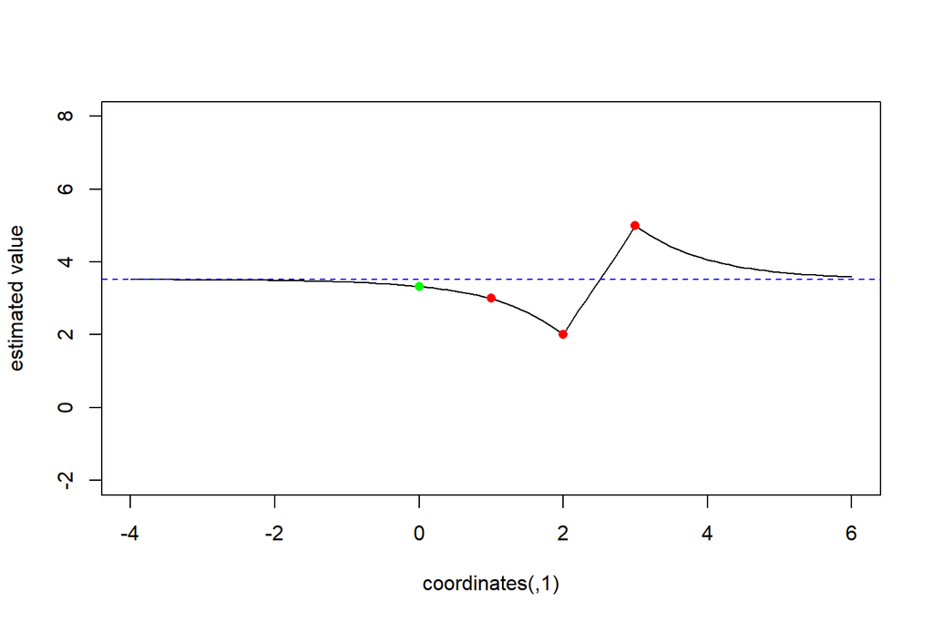

## Universal Kriging - Example:

Linear trend:

estimated value at prediction location ~1.7

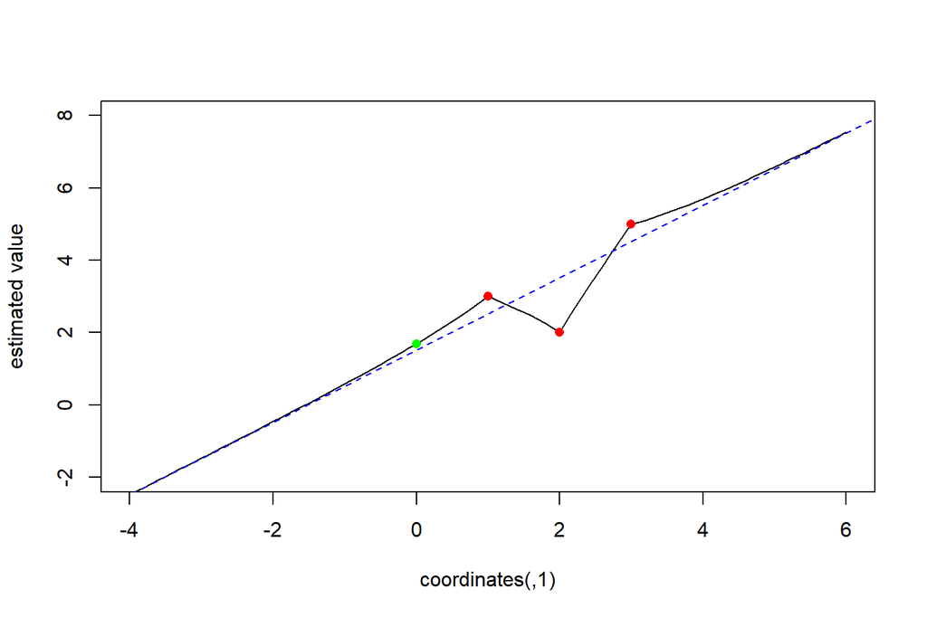

## Universal Kriging - Example:

With Gaussian covariance:

estimated value at prediction location ~2.06

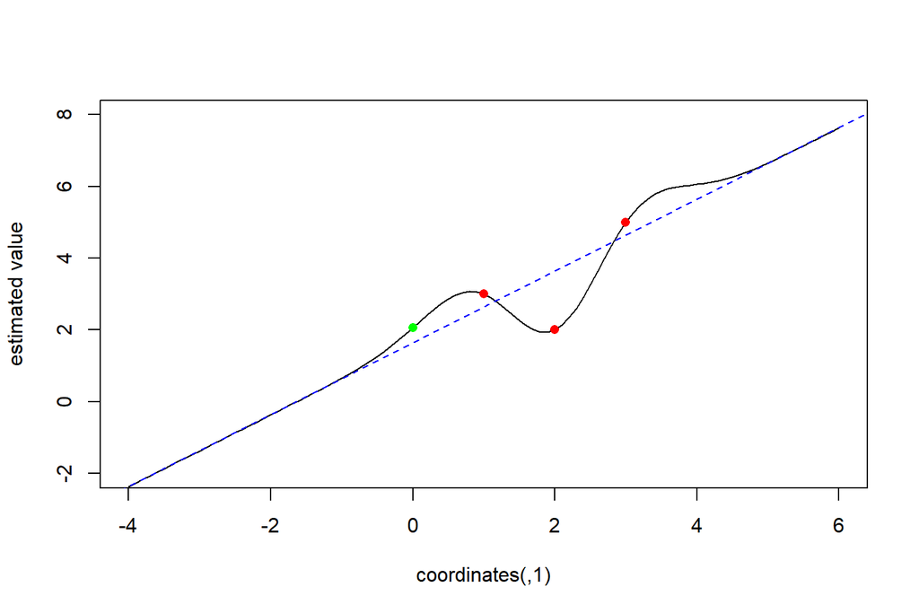

## Estimating spatial correlation under the UK model

As opposed to the ordinary kriging model, the universal kriging model needs knowledge of the mean vector in order to estimate the semivariance (or covariance) from the residual vector:
$$\hat{e}(s) = Z(s) - X\hat\beta$$
but how to get $\hat\beta$ without knowing $V$? This is a chicken-egg problem. The simplest, but not best, solution is to plug $\hat{\beta}_{OLS}$ in, and from the $e_{OLS}(s)$, estimate $V$ (i.e., the variogram of $Z$)

## Universal Kriging workflow

- choose predictors for the mean (e.g. distance to river for zinc concentration)
- fit a linear regression model (estimate $\beta$)
- model mean for known locations and calculate residuals (differences to mean)
- fit a (semi-) variogram to the residuals
- apply kriging on the residuals
- apply the regression model on all prediction points
- at each prediction location add the (modeled) mean and the (modeled) residual

## Spatial Prediction

… involves errors, uncertainties

## UK and linear regression

If $Z$ has no spatial correlation, all covariances are zero and $v=0$ and $V=\mbox{diag}(\sigma^2)$. This implies that
$$\hat{Z}(s_0) = x(s_0)\hat{\beta} + v'V^{-1} (Z-X\hat{\beta})$$
with $\hat{\beta} = (X'V^{-1}X)^{-1} X'V^{-1}Z$ reduces to

$$\hat{Z}(s_0) = x(s_0)\hat{\beta}$$
with $\hat{\beta} = (X'X)^{-1} X'Z$, i.e., ordinary least squares regression.

## UK and linear regression

Note that

- under this model the residual does not carry information, as it is white noise
- in spatial prediction, UK can not be worse than linear regression, as linear regression is a limiting case of a more general model.

## Application

For an application of universal kriging in mapping of air quality variables, and a comparison to linear regression, see

- Rob Beelen, Gerard Hoek, Edzer Pebesma, Danielle Vienneau, Kees de Hoogh, David J. Briggs, Mapping of background air pollution at a fine spatial scale across the European Union, Science of The Total Environment, Volume 407, Issue 6, 2009, Pages 1852-1867, https://doi.org/10.1016/j.scitotenv.2008.11.048

## Kriging varieties

**Simple kriging:** $Z(s)=\mu+e(s)$, $\mu$ known

**Ordinary kriging:** $Z(s)=m+e(s)$, $m$ unknown

**Universal kriging:** $Z(s)=X\beta+e(s)$, $\beta$ unknown

## Kriging varieties

- SK: $\lambda'Z$ with $\lambda$ such that $\sigma^2(s_0) = {\rm E}(Z(s_0)-\lambda'Z)^2$ is minimized
- OK: $\lambda'Z$ with $\lambda$ such that it
  - has minimum variance $\sigma^2(s_0) = {\rm E}(Z(s_0)-\lambda'Z)^2$, and
  - is unbiased ${\rm E}(\lambda'Z) = m$
  - second constraint: $\sum_{i=1}^n \lambda_i = 1$, weights sum to one.
- UK:
  - $\hat{Z}(s_0) = x(s_0)\hat{\beta} + v'V^{-1} (Z-X\hat{\beta})$ with
  - $\hat{\beta} = (X'V^{-1}X)^{-1} X'V^{-1}Z$
  - $\sigma^2(s_0) = \sigma^2_0 - v'V^{-1}v + Q$

## Global vs. local predictors

In many cases, instead of using all data, the number of observations used for prediction are limited to a selection of nearest observations, based on

- number of observations or
- distance to prediction location $s_0$
- possibly, in addition, directions

The reason for this is usually either

- statistical, allowing for a more flexible mean/trend structure
- practical, if $n$ gets large

## Statistical arguments for local prediction

- estimating $\beta$ locally instead of globally means that
  - $\beta$ will adjust to local situations (less bias)
  - it will be harder to estimate $\beta$ from less information, so (slightly?) larger prediction errors will result (larger variance)
- some authors claim that local trends are so adaptive, that one can ignore spatial correlation of the residual
- Using local linear regression with *weights* that decay with distance is called *geographically weighted regression*, GWR

## Practical arguments for local prediction

- The number of observations, $n$ may become very large -lidar data, 3D chemical, satellite sensors, geotechnical, seismic, …
- Computing $V^{-1}v$ is the expensive part; it is $O(N^2)$ or $O(N^3)$ as $V$ is usually not of simple structure
- there is a trade-off; for a global neighbourhood, the expensive part, factoring $V$ needs only be done once, for a local neighbourhood for each unique neighbourhood (in practice: for each $s_0$).
- selecting local neighbourhoods also costs time; naive selection $O(n \log n)$ doesn’t scale well
- `gstat` uses quadtrees/octtrees, inspired by http://donar.umiacs.umd.edu/quadtree/index.html

## Predicting block means - Block Kriging

Instead of predicting $Z(s_0)$ for a ‘’point’’ location, one might be interested in predicting the average of $Z(s)$ over a block, $B_0$, i.e.
$$Z(B_0) = \frac{1}{|B_0|}\int_{B_0} Z(u)du$$

## Predicting block means - Block Kriging

- This can (naively) be done by predicting $Z$ over a large number of points $s_0$ inside $B_0$, and averaging
- For the prediction *error*, of $\hat{Z}(B_0)$, we then need the covariances between all point predictions

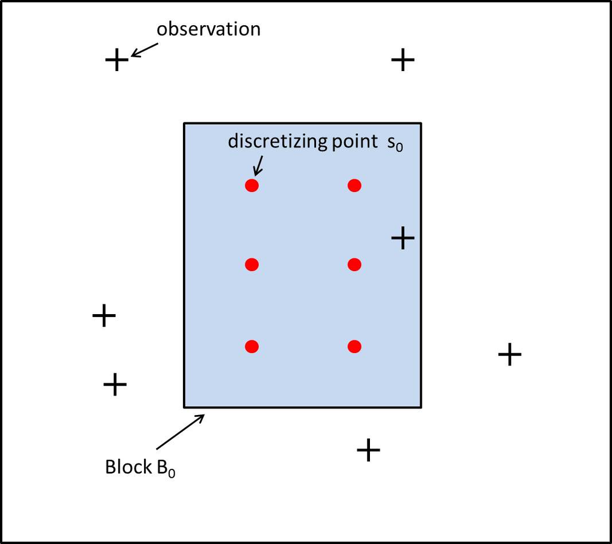

## Predicting block means - Block Kriging

- this can be computationally expensive, especially when many block estimates are required
- a more efficient way is to use block kriging, which does prediction and averaging at once, so only one kriging system is needed for each block estimate
- the estimate produced by block kriging is identical to that obtained by averaging the point estimates
  - the average of the point estimates is the same as the direct block estimate
  - the average of the point kriging weights for a sample is the same as the block kriging weight for the sample
- when using block kriging variance decreases because variability cancels out

## Block Kriging - how to discretize blocks

- the grid of discretizing points should always be regular
- the spacing between points may be larger in one direction than in the other to account for anisotropy

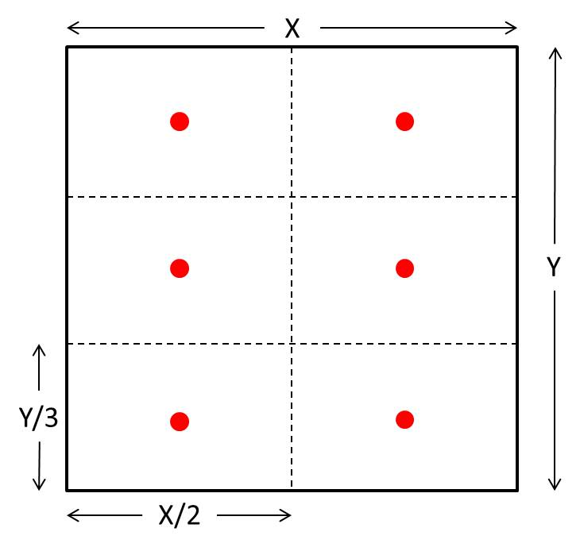

## Reason why one wants block means

Examples

- mining: we cannot mine point values
- soil remediation: we cannot remediate points
- RS: we can match satellite image pixels
- disaster management: we cannot evacuate points
- environment: legislation may be related to blocks
- accuracy: block means can be estimated with smaller errors than points

[figure not shown]